# Avaliação Continuada - Aula 10

**Execute a célula a seguir para importar as bibliotecas de que vamos precisar e criar a variável `taxis` com nossa base de dados.**

```python
# Importando a biblioteca seaborn
import seaborn as sns
import matplotlib.pyplot as plt

# Carregando a base de dados 'taxis'
taxis = sns.load_dataset("taxis")

taxis["card_payment"] = taxis["payment"] == "credit card"

taxis.head()
```

|  | pickup | dropoff | passengers | distance | fare | tip | tolls | total | color | payment | pickup_zone | dropoff_zone | pickup_borough | dropoff_borough | card_payment |
| --- | --- | --- | --- | --- | --- | --- | --- | --- | --- | --- | --- | --- | --- | --- | --- |
| 0 | 2019-03-23 20:21:09 | 2019-03-23 20:27:24 | 1 | 1.60 | 7.0 | 2.15 | 0.0 | 12.95 | yellow | credit card | Lenox Hill West | UN/Turtle Bay South | Manhattan | Manhattan | True |
| 1 | 2019-03-04 16:11:55 | 2019-03-04 16:19:00 | 1 | 0.79 | 5.0 | 0.00 | 0.0 | 9.30 | yellow | cash | Upper West Side South | Upper West Side South | Manhattan | Manhattan | False |
| 2 | 2019-03-27 17:53:01 | 2019-03-27 18:00:25 | 1 | 1.37 | 7.5 | 2.36 | 0.0 | 14.16 | yellow | credit card | Alphabet City | West Village | Manhattan | Manhattan | True |
| 3 | 2019-03-10 01:23:59 | 2019-03-10 01:49:51 | 1 | 7.70 | 27.0 | 6.15 | 0.0 | 36.95 | yellow | credit card | Hudson Sq | Yorkville West | Manhattan | Manhattan | True |
| 4 | 2019-03-30 13:27:42 | 2019-03-30 13:37:14 | 3 | 2.16 | 9.0 | 1.10 | 0.0 | 13.40 | yellow | credit card | Midtown East | Yorkville West | Manhattan | Manhattan | True |

### Sobre os dados

No exercício de hoje, vamos utilizar as seguintes variáveis:

- `dropoff_borough`: bairro onde o passageiro foi deixado.
- `fare`: valor da corrida, em dólares ($).
- `card_payement`: indica se a corrida foi paga com cartão de crédito (1) ou não (0).
- `pickup_borough`: bairro onde o passageiro pegou sua corrida.

Nosso objetivo é verificar se há alguma relação entre essas variáveis.

### Exercício de hoje - Parte 1

Utilize a função `query` para selecionar apenas as linhas de corridas que começaram em Manhattan (`"pickup_borough == 'Manhattan'"`).

Salve o resultado em uma variável chamada `manhattan_taxis`.

```python
# continue o código abaixo
manhattan_taxis = taxis

# gabarito
manhattan_taxis = taxis.query("pickup_borough == 'Manhattan'")
```

### Exercício de hoje - Parte 2

Seu trabalho hoje é modificar o gráfico abaixo explicando o achado de nossa análise.

Antes de executar as células abaixo você deve ter feito a parte 1 do exercício.

Você deve partir do gráfico abaixo, e deverá adicionar informações para facilitar sua interpretação:

(Não mexa na célula a seguir. Há instruções e uma célular para você fazer seu código logo abaixo.)

[figure not shown]

```python
sns.barplot(
    x="dropoff_borough",
    y="card_payment",
    data=manhattan_taxis,
)
```

Sua tarefa é modificar o código abaixo para:

1. Remover a barra de erro do gráfico, usando o argumento `errorbar`
2. Adicionar um título que explique qual o significado de cada barra.
3. Adicionar o valor de cada barra ao gráfico

[output not shown]

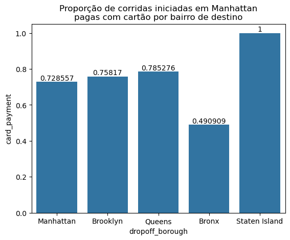

```python
fig, ax = plt.subplots()

sns.barplot(
    x="dropoff_borough",
    y="card_payment",
    data=manhattan_taxis,
    ax=ax,
    # remova o # para descomentar a linha abaixo
    errorbar=None,
)

# adicione seu código abaixo

# o título deve ter um texto com informações parecidas com esse:
ax.set_title("Proporção de corridas iniciadas em Manhattan\npagas com cartão por bairro de destino")
# adiciona os valores de cada barra:
ax.bar_label(ax.containers[0])
```